# When are we going home? An examination of provider discharge predictions in the NICU

Leah Carr

### Overview

Predicting time to discharge in neonatal patient care is complex, but essential as neonatal intensive care units (NICUs) need to anticipate unit census for patient admission and staffing purposes and to ensure safe and effective patient transitions to home. As a component of a patient safety and quality improvement (QI) initiative in the CHOP NICU, a checklist was implemented that uses provider-endorsed time windows to aid in discharge predictions. This project explores provider predictive accuracy and factors that might contribute to individuals who discharge at times outside their predicted window.

My final Github repository can be accessed here: https://github.com/carrlh/BMIN-503-final-project

### Introduction

In the NICU, the youngest hospital patients receive complex care. With nearly 10% of infants in the United States being born premature and a subset of term infants requiring assistance, NICUs provide essential care to a vulnerable patient population. Thankfully, since the first NICU in the United States opened, infant mortality has drastically decreased and many more patients admitted to the NICU are able to be discharged. Anticipation of discharge is key to patient-specific and unit-wide planning. As NICU patients prepare to leave the unit, plans are set in place for medical and supportive care. An anticipated discharge timeframe allows for medications to be prepped, homecare supplies to be delivered, and for families to mentally prepare to take their infants home. Incorrect predictions can lead to delays in discharge, which are not only disappointing, but can have significant implications beyond individual patients. For referral centers, units often admit patients needing coordinated, high-level care or those coming in post-operatively from elective procedures. For these units, discharge timeframes inform whether or not they will have bed space available for admissions. In addition, discharge anticipation is also needed for staff scheduling. While there is a body of literature examining NICU provider predictions of patient mortality, there is limited information regarding provider’s perceptions of time to discharge.

The importance of anticipating discharge timing is not unique to the field of neonatology. Principles and findings from this exploratory analysis can be applied across hospital units that seek to better understand their discharge practices. All hospitals are interested in better understanding what contributes to their ability to admit and discharge patients, whether for patient care and safety purposes or as a component of their business models. Through discussions with Dr. Nicolas Bamat, a neonatal clinical researcher, I was able to better define my demographic characteristics and potential factors influencing discharge. I then connected with two CHOP data analysts, Matt Devine and Jake Riley, who aided in data extraction and analytic planning.

Using data collected from a CHOP NICU QI and safety rounding tool as well as electronic health record (EHR) data taken from EPIC, I aim to evaluate the quality of NICU providers’ abilities to predict discharge and to further assess what factors contribute to incorrect assessments. The discharge-specific component of the tool is currently used as a trigger for multiple aspects of discharge planning, but data regarding its accuracy have yet to be analyzed.

### Methods

Data was obtained through a SQL query of the CHOP Clinical Data Warehouse. The specific data pulled included responses to a weekly question to NICU providers asking them when they anticipate that a patient will discharge. Data was taken from October, 2019 through the end of October, 2020. Providers respond to this question by clicking a button in the EHR with “today,” “<3 days,” “3-7 days,” “7-14 days,” or “no date identified” as potential answer choices. In addition to the actual discharge prediction, the timing of the discharge prediction, and when a patient actually discharged, the query included identifiers (pat_key, visit_key), demographics (gestational age, corrected gestational age, sex, race, ethnicity), patient characteristics (insurance carrier, government vs. commercial insurance categorization, primary and secondary hospital diagnoses and associated ICD-10 codes, presence of a central line [0 - no central line, 1 - central line placed after the question was asked, 2 - central line present at the time the question was asked], presence of an endotracheal tube [numerical coding is the same as with central lines], and whether or not the patient was on IV medications or fluids [again, coding was the same]). In addition, information regarding the accuracy of discharge prediction (0 - inaccurate, 1 - accurate) was pulled.

The data was then opened in R Studio where it was deidentified, cleaned, and then analyzed. The deidentification process involved removal of the pat_key, substitution of values for the visit_key, and removal of all dates instead favoring use of relative values (e.g. time off from anticipated discharge window).

Next, the data was manipulated to examine rates of accuracy across all entries, then accuracy across first prediction vs. last prediction (prediction closest to the time of discharge). Then, bivariate analysis was completed to examine what factors contributed to prediction accuracy. The most significant mediators were then used in logistic regression to further characterize relationships between accuracy and our predictors. Linear regression was then used to further examine factors contributing to the degree of provider inaccuracy. Specifics regarding the code are shown below in the chunks below.

The initial data analysis involved deidentifying the information from a “base” dataset with some cleaning to add columns based off of the timing of discharge using the code featured below.

#### Initial data cleaning

```r
#pull in necessary packages
library(tidyverse)
library(lubridate)
library(RColorBrewer)
library(broom)
library(knitr)

#make bar graphs have a grey outline
update_geom_defaults(geom = "bar", list(color = "grey70"))

#pull in data
base_data <- read.csv("ccq_discharge_predictions.csv") %>% #pull in file, rename dataframe as "base_data"
  rename_all(tolower) %>% #format all variables to lowercase
  mutate(
    prediction_entry_date = mdy(prediction_entry_date), #modify date formatting
    discharge_calendar_date = as.Date(mdy_hm(discharge_calendar_date)),
    discharge_prediction_lower_bound = as.Date(mdy(discharge_prediction_lower_bound)),
    discharge_prediction_upper_bound = as.Date(mdy(discharge_prediction_upper_bound))
  )

#determine what is the appropriate key column to include and filter on
pat_key_count <- count(base_data, pat_key) #note there are 854 pat keys (representing each patient)
visit_key_count <- count(base_data, visit_key) #note there are 875 visit keys representing visits (important for determining if patients were readmitted, this is the more important factor to include as there is evidence of patients moving in and out of the unit)

#deidentify and further clean data for csv file that can be shared
anon_data <- base_data %>%
   mutate(
     diff = case_when(
    discharge_calendar_date < discharge_prediction_lower_bound ~ discharge_calendar_date - discharge_prediction_lower_bound,
    discharge_calendar_date <= discharge_prediction_upper_bound ~ 0,
    TRUE ~ discharge_calendar_date - discharge_prediction_upper_bound)
    ) %>% #make a new column looking at how off we are from the predicted time window to be used in later analysis
    mutate(visit_key = dense_rank(visit_key)) %>%  #for deidentification, modification of the visit keys to random numbers
  group_by(visit_key) %>%
  mutate(est_number = rank(prediction_entry_date)) %>% #make a new column that ranks the number of estimates by prediction entry date for later use
  ungroup() %>%
  dplyr::select(-c(pat_key, prediction_entry_date, prediction_recorded_timestamp, discharge_calendar_date, discharge_prediction_lower_bound, discharge_prediction_upper_bound, payor_name, corrected_age_in_wks_at_prediction, ethnicity)) #remove unnecessary columns for future analysis and to maintain anonymity

write_csv(anon_data, 'carr_anon_data.csv')

#pull in deidentified data for further cleaning
clean_data <- read.csv("carr_anon_data.csv") %>%
  mutate(discharge_prediction = str_replace_all(discharge_prediction, "no date identied", "no date identified")) %>% #typo noted in some of the data, corrected using stringr
  rename(dx1_name = primary_hsp_account_dx_name) %>% #rename columns to make it easier for data manipulation later on
  rename(dx1_icd10 = primary_hsp_account_dx_icd10) %>%
  rename(dx2_name = secondary_dx) %>%
  rename(dx2_icd10 = secondary_dx_icd10) %>%
  filter(deceased_ind == 0) %>% #remove individuals who did not survive
  mutate(gest_age_groups = cut(gestational_age_complete_weeks, breaks=c(-Inf, 25, 30, 35, Inf), labels=c("<25 weeks","25-30 weeks","30-35 weeks", ">35 weeks"))) %>% #categorize gestational age for further analysis
  filter(gest_age_groups != "NA") %>% #remove NA gest age values
  filter(sex != "U") #remove unidentifed sex values
```

#### Visualizing prediction response frequency

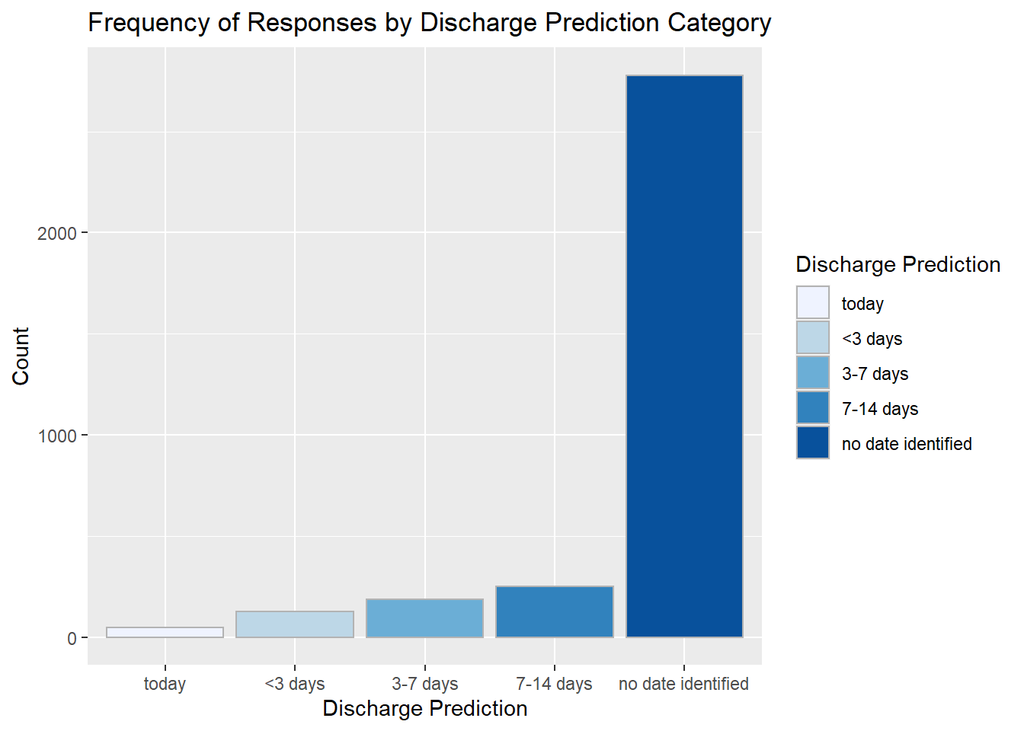

```r
#visualization of prediction responses
clean_data %>%
  count(discharge_prediction) %>%
  ggplot(aes(x = reorder(discharge_prediction, n), y = n, fill = reorder(discharge_prediction, n))) +
  geom_bar(stat = 'identity') +
  labs(title = "Frequency of Responses by Discharge Prediction Category", x = "Discharge Prediction", y = "Count") +
  scale_fill_brewer(palette = "Blues", name = "Discharge Prediction")
```

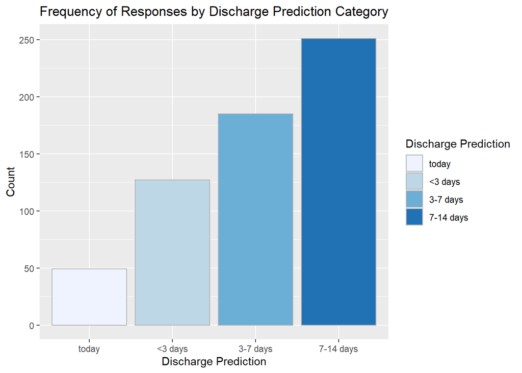

```r
#visualization of prediction responses with only "identified" responses
clean_data %>%
  count(discharge_prediction) %>%
  filter(discharge_prediction != "no date identified") %>%
  ggplot(aes(x = reorder(discharge_prediction, n), y = n, fill = reorder(discharge_prediction, n))) +
  geom_bar(stat = 'identity') +
  labs(title = "Frequency of Responses by Discharge Prediction Category", x = "Discharge Prediction", y = "Count") +
  scale_fill_brewer(palette = "Blues", name = "Discharge Prediction")
```

```r
#Examine patients who have no date identified and how far away they actually are from discharge
no_date_identified <- clean_data %>%
  filter(discharge_prediction == "no date identified")

mean(no_date_identified$days_until_discharge) #examine mean "days until discharge" of patients with no date identified
```

```
## [1] 74.29579
```

We see a large number of “no date identified” responses. When these are removed, we see progression from predictions of “today” to “7-14 days” in terms of increasing response frequency. Among those patients who have no identified discharge date, they are discharged an average of 74 days from the time the estimation is made.

### Results

#### Overall accuracy of predictions

```r
#make a dataframe looking at how providers anticipated discharge
pred_descrip <- clean_data %>%
  dplyr::select(visit_key, discharge_prediction, days_until_discharge, accurate_prediction_ind)

#look at total number of prediction types
discharge_pred_count <- pred_descrip %>% #make a new dataframe
  count(discharge_prediction) %>%  #count the number of predictions in each prediction group
  rename("total_predictions" = "n") %>% #rename prediction column
  filter(discharge_prediction != "no date identified") #look at all patients who had a prediction time window (remove those without an identified date)

#look at accuracy counts by discharge prediction timeline
accurate_pred_count <- pred_descrip %>%
  group_by(discharge_prediction) %>%
  filter(accurate_prediction_ind == 1) %>%
  count(accurate_prediction_ind) %>%
  rename("total_accurate_predictions" = "n")

#look at accuracy rates
pred_accuracy_rates <- inner_join(accurate_pred_count, discharge_pred_count, by = "discharge_prediction") %>% #make a new dataframe that looks at accuracy rates
  dplyr::select(-c(accurate_prediction_ind)) %>% #remove the accuracy indicator
  mutate(accuracy = round(total_accurate_predictions/total_predictions, 3) * 100) %>% #calculate accuracy rate
  arrange(accuracy) %>% #reorder
  mutate(time = "overall")

pred_accuracy_rates
```

| discharge_prediction | total_accurate_predictions | total_predictions | accuracy | time |
| --- | --- | --- | --- | --- |
| 7-14 days | 102 | 251 | 40.6 | overall |
| 3-7 days | 91 | 185 | 49.2 | overall |
| <3 days | 84 | 127 | 66.1 | overall |
| today | 47 | 49 | 95.9 | overall |

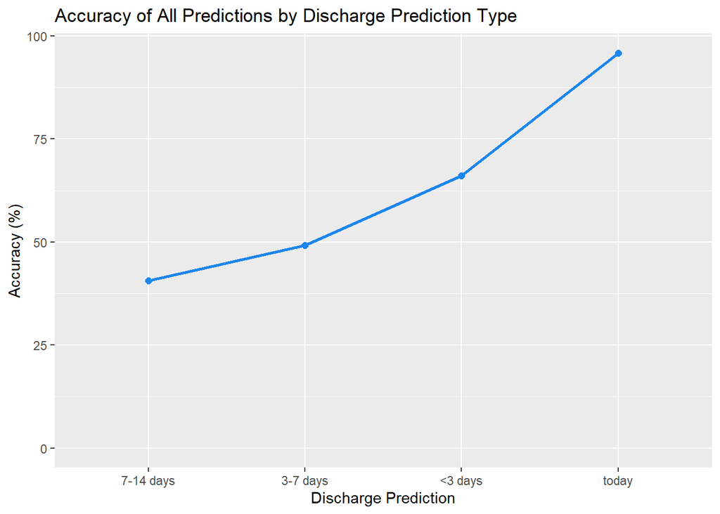

```r
#visualization of the accuracy of all predictions
pred_accuracy_rates$discharge_prediction <-
  factor(pred_accuracy_rates$discharge_prediction,
         levels = pred_accuracy_rates$discharge_prediction[order(pred_accuracy_rates$accuracy)]) #reorder for graphing purposes

ggplot(data = pred_accuracy_rates, aes(x = discharge_prediction, y = accuracy, group = 1)) + #graph our predictions
  geom_line(color = "dodgerblue2", size = 1) + #customize line color and size
  geom_point(color = "dodgerblue2", size = 2) + #customize point color and size
  labs(title = "Accuracy of All Predictions by Discharge Prediction Type", x = "Discharge Prediction", y = "Accuracy (%)") + #add in titles
  ylim(0, NA) #make the y-axis start at 0
```

We get more accurate in predicting time of discharge as a patient gets closer to discharge

#### Dataframe creation of first and last predictions

```r
first_est <- clean_data %>%
  group_by(visit_key) %>% #group by the patient IDs
  filter(est_number == 1) %>% #look only at the first estimates
  ungroup()

last_est <- clean_data %>%
  group_by(visit_key) %>% #group by the patient IDs
  filter(est_number == max(est_number)) %>% #look only at the last estimates
  ungroup()
```

#### Accuracy of initial predictions

```r
#look at total number of prediction types
first_est_discharge_pred_count <- first_est %>% #make a new dataframe
  dplyr::select(visit_key, discharge_prediction, days_until_discharge, accurate_prediction_ind) %>%
  group_by(discharge_prediction) %>%
  count(discharge_prediction) %>%  #count the number of predictions in each prediction group
  rename("total_predictions" = "n") %>% #rename prediction column
  filter(discharge_prediction != "no date identified") #look at all patients who had a prediction time window (remove those without an identified date)

#look at accuracy counts by discharge prediction timeline
first_est_accurate_pred_count <- first_est %>%
  dplyr::select(visit_key, discharge_prediction, days_until_discharge, accurate_prediction_ind) %>%
  group_by(discharge_prediction) %>%
  filter(accurate_prediction_ind == 1) %>%
  count(accurate_prediction_ind) %>%
  rename("total_accurate_predictions" = "n")

#look at accuracy rates
first_est_pred_accuracy_rates <- inner_join(first_est_accurate_pred_count, first_est_discharge_pred_count, by = "discharge_prediction") %>% #make a new dataframe that looks at accuracy rates
  dplyr::select(-c(accurate_prediction_ind)) %>% #remove the accuracy indicator
  mutate(accuracy = round(total_accurate_predictions/total_predictions, 3) * 100) %>% #calculate accuracy rate
  arrange(accuracy) %>% #reorder
  mutate(time = "first")

first_est_pred_accuracy_rates
```

| discharge_prediction | total_accurate_predictions | total_predictions | accuracy | time |
| --- | --- | --- | --- | --- |
| 7-14 days | 44 | 85 | 51.8 | first |
| 3-7 days | 39 | 74 | 52.7 | first |
| <3 days | 37 | 55 | 67.3 | first |
| today | 16 | 17 | 94.1 | first |

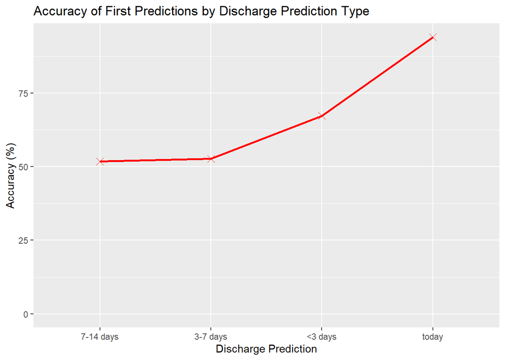

```r
#visualization of the accuracy for first predictions
first_est_pred_accuracy_rates$discharge_prediction <- factor(first_est_pred_accuracy_rates$discharge_prediction, levels = first_est_pred_accuracy_rates$discharge_prediction[order(first_est_pred_accuracy_rates$accuracy)]) #reorder for graphing purposes

ggplot(data = first_est_pred_accuracy_rates, aes(x = discharge_prediction, y = accuracy, group = 1)) + #graphing accuracy
  geom_line(color = "red", size = 1) + #customize line color, size
  geom_point(color = "red", shape = 4, size = 3) + #customize point color, shape, and size
  labs(title = "Accuracy of First Predictions by Discharge Prediction Type", x = "Discharge Prediction", y = "Accuracy (%)") + #add titles
  ylim(0, NA) #make y-axis start at 0
```

Using just first estimates, we remain most accurate at the timepoints closest to discharge (<3 days and today).

#### Accuracy of final predictions

```r
#look at total number of prediction types
last_est_discharge_pred_count <- last_est %>% #make a new dataframe
  dplyr::select(visit_key, discharge_prediction, days_until_discharge, accurate_prediction_ind) %>%
  group_by(discharge_prediction) %>%
  count(discharge_prediction) %>%  #count the number of predictions in each prediction group
  rename("total_predictions" = "n") %>% #rename prediction column
  filter(discharge_prediction != "no date identified") #look at all patients who had a prediction time window (remove those without an identified date)

#look at accuracy counts by discharge prediction timeline
last_est_accurate_pred_count <- last_est %>%
  dplyr::select(visit_key, discharge_prediction, days_until_discharge, accurate_prediction_ind) %>%
  group_by(discharge_prediction) %>%
  filter(accurate_prediction_ind == 1) %>%
  count(accurate_prediction_ind) %>%
  rename("total_accurate_predictions" = "n")

#look at accuracy rates
last_est_pred_accuracy_rates <- inner_join(last_est_accurate_pred_count, last_est_discharge_pred_count, by = "discharge_prediction") %>% #make a new dataframe that looks at accuracy rates
  dplyr::select(-c(accurate_prediction_ind)) %>% #remove the accuracy indicator
  mutate(accuracy = round(total_accurate_predictions/total_predictions, 3) * 100) %>% #calculate accuracy rate
  arrange(accuracy) %>% #reorder
  mutate(time = "last")

last_est_pred_accuracy_rates
```

| discharge_prediction | total_accurate_predictions | total_predictions | accuracy | time |
| --- | --- | --- | --- | --- |
| 7-14 days | 38 | 113 | 33.6 | last |
| 3-7 days | 80 | 132 | 60.6 | last |
| <3 days | 84 | 115 | 73.0 | last |
| today | 47 | 49 | 95.9 | last |

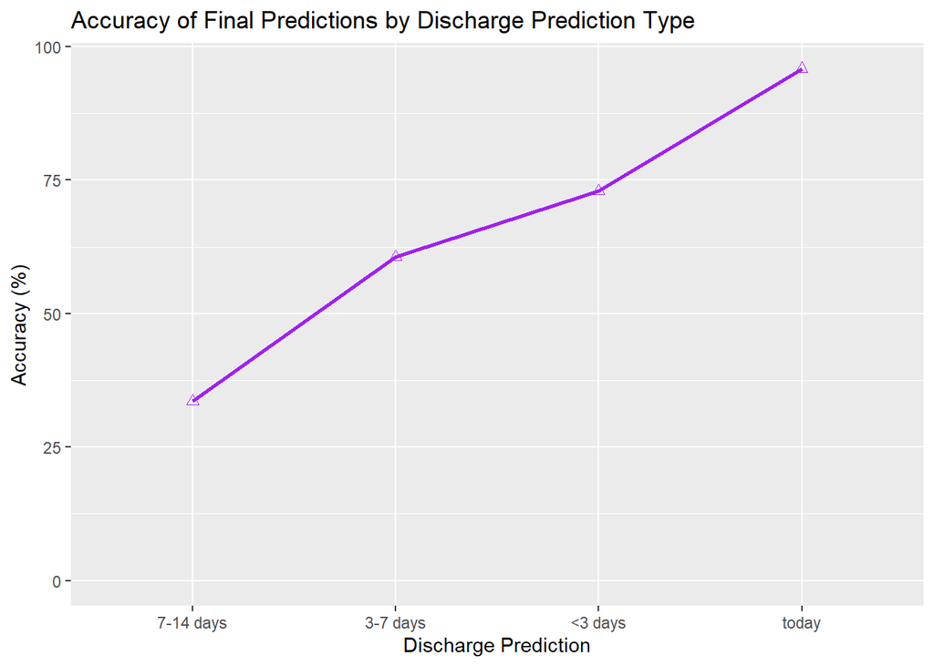

```r
#visualization of the accuracy for final predictions
last_est_pred_accuracy_rates$discharge_prediction <- factor(last_est_pred_accuracy_rates$discharge_prediction, levels = last_est_pred_accuracy_rates$discharge_prediction[order(last_est_pred_accuracy_rates$accuracy)]) #reorder for graphing purposes

ggplot(data = last_est_pred_accuracy_rates, aes(x = discharge_prediction, y = accuracy, group = 1)) + #graph accurary rates
  geom_line(color = "purple", size = 1) + #customize line color and size
  geom_point(color = "purple", shape = 2, size = 2) + #customize point color, shape, and size
  labs(title = "Accuracy of Final Predictions by Discharge Prediction Type", x = "Discharge Prediction", y = "Accuracy (%)") + #add titles
  ylim(0, NA) #make y-axis start at 0
```

Using just the estimate closest to the date of discharge, we see the same trend, we are more accurate at predicting discharge at timepoints closest to going home.

#### Accuracy across groups

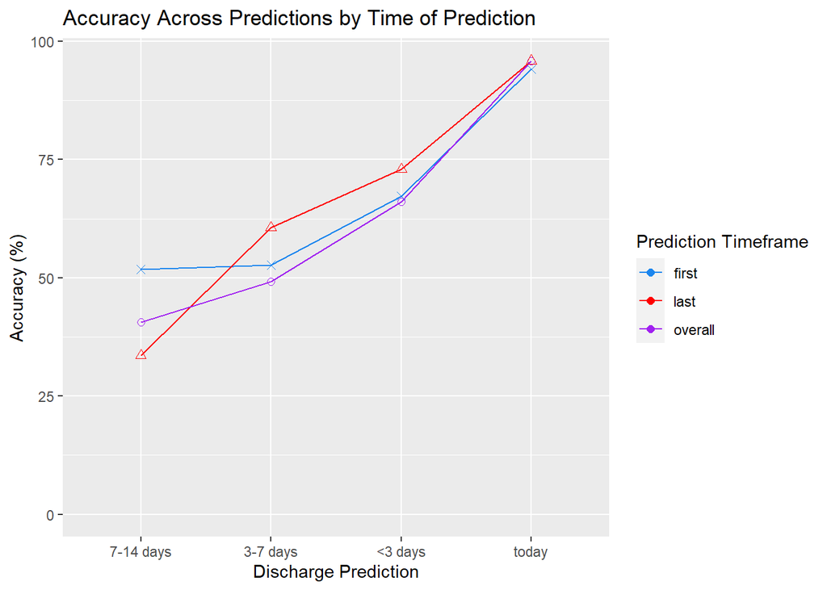

```r
accuracy_by_type <- bind_rows( #make a dataframe that looks at all groups
  pred_accuracy_rates,
  first_est_pred_accuracy_rates,
  last_est_pred_accuracy_rates
) %>%
  mutate(shape = recode(time, overall = "1", first = "4", last = "2") %>% #make it so that our custom shapes will pull in
           as.integer())

ggplot(accuracy_by_type, aes(x = discharge_prediction, y = accuracy, group = time, color = time, shape = shape)) + #graph accuracy in all three groups
  geom_line() +
  geom_point(size = 2) +
  labs(title = "Accuracy Across Predictions by Time of Prediction", x = "Discharge Prediction", y = "Accuracy (%)", color = "Prediction Timeframe") + #add columns
  ylim(0, NA) +
  scale_color_manual(values = c("dodgerblue2", "red", "purple")) + #make the legend colors appropriate
  scale_shape_identity()
```

We see that across the groups, our similar trend is again seen; however, at the time of final prediction (i.e. the one closest to the time of discharge), we become more accurate than in our overall or first prediction group as we near discharge.

#### Between-groups analysis

```r
#make a new dataframe for analyzing statistical diff between groups with predicted discharge "today"
accuracy_by_type_chi_today <- accuracy_by_type %>%
  filter(discharge_prediction == "today") %>%
  dplyr::select(accuracy, discharge_prediction, time) %>%
  {
  chisq.test(xtabs(accuracy ~ time, data = .))
    } %>%
  print()
```

```
##
##  Chi-squared test for given probabilities
##
## data:  xtabs(accuracy ~ time, data = .)
## X-squared = 0.022665, df = 2, p-value = 0.9887
```

```r
#make a new dataframe for analyzing statistical diff between groups with predicted discharge at "<3 days"
accuracy_by_type_chi_less3 <- accuracy_by_type %>%
  filter(discharge_prediction == "<3 days") %>%
  dplyr::select(accuracy, discharge_prediction, time) %>%
  {
  chisq.test(xtabs(accuracy ~ time, data = .))
    } %>%
  print()
```

```
##
##  Chi-squared test for given probabilities
##
## data:  xtabs(accuracy ~ time, data = .)
## X-squared = 0.39506, df = 2, p-value = 0.8208
```

```r
#make a new dataframe for analyzing statistical diff between groups with predicted discharge at "3-7 days"
accuracy_by_type_chi_37 <- accuracy_by_type %>%
  filter(discharge_prediction == "3-7 days") %>%
  dplyr::select(accuracy, discharge_prediction, time) %>%
  {
  chisq.test(xtabs(accuracy ~ time, data = .))
    } %>%
  print()
```

```
##
##  Chi-squared test for given probabilities
##
## data:  xtabs(accuracy ~ time, data = .)
## X-squared = 1.2592, df = 2, p-value = 0.5328
```

```r
#make a new dataframe for analyzing statistical diff between groups with predicted discharge at "7-14 days"
accuracy_by_type_chi_714 <- accuracy_by_type %>%
  filter(discharge_prediction == "7-14 days") %>%
  dplyr::select(accuracy, discharge_prediction, time) %>%
  {
  chisq.test(xtabs(accuracy ~ time, data = .))
    } %>%
  print()
```

```
##
##  Chi-squared test for given probabilities
##
## data:  xtabs(accuracy ~ time, data = .)
## X-squared = 4.0133, df = 2, p-value = 0.1344
```

Despite the differences seen between the groups on the graph, these differences are not statistically significant based on the chi-squared testing.

#### Diagnosis information cleaning

```r
dx_total <- clean_data %>%
  group_by(visit_key) %>% #group by the patient IDs
  filter(est_number == 1) %>% #filter based off of first prediction
  ungroup() %>%
  dplyr::select(dx1_icd10, dx2_icd10) %>%
  gather(key = "source", value = "dx") %>% #place diagnoses in one column
  add_count(short_dx = substr(dx, 1, 5)) %>%  #look only at first 4 characters in the ICD codes
  mutate(n = ifelse(short_dx == "Z38.0", 0, n)) %>% #Z38.0 is a diagnosis I'm uninterested in (it describes birth status), so I want this removed
  distinct(dx, n) %>% #maintaining granularity, but eliminating our short column
  print()
```

```
## # A tibble: 355 x 2
##    dx         n
##    <chr>  <dbl>
##  1 Z38.01     0
##  2 I27.20     5
##  3 Z38.00     0
##  4 Z38.31    31
##  5 P27.1     29
##  6 J96.22     6
##  7 K56.50     3
##  8 P27.8     22
##  9 J21.0     32
## 10 J96.01    27
## # ... with 345 more rows
```

```r
dx_1 <- dx_total %>% #new dataframe for primary diagnoses
  rename(dx1_icd10 = dx,
         dx1_n = n) #renaming the dx column for the primary diagnosis group to prepare to join it with the secondary diagnoses

dx_2 <- dx_total %>% #new dataframe for secondary diagnoses
  rename(dx2_icd10 = dx,
         dx2_n = n) #renaming the dx column for the secondary diagnosis group to prepare to join it with the primary diagnoses

clean_data <- clean_data %>%
  left_join(dx_1) %>% #join in dx_1 and dx_2 to clean data
  left_join(dx_2) %>%
  mutate(top_dx =
    case_when(dx1_n >= dx2_n ~ dx1_icd10,
              TRUE ~ dx2_icd10) #bring back the more common diagnosis to then be used in logistic regression
  ) %>%
  mutate(top_dx = substr(top_dx, 1, 5)) #limit the length of the diagnosis string
```

Based on this investigation, I will use a select grouping of the most common diagnoses in my dataset for use in later statistical testing (P28.5 - respiratory failure of the newborn, p29.3 - pulmonary hypertension, Q79.0 - congenital diaphragmatic hernia, J21.0 - bronchiolitis due to respiratory syncitial virus, P91.6 - hypoxic ischemic encephalopathy)

#### Bivariate analysis

```r
#Bivariate analysis was completed to look at potential factors contributing to accuracy. First data was cleaned further and an additional dataframe examining the order of predictions was created.

#new dataframe created for further analysis
rank_data <- clean_data %>%
  group_by(visit_key) %>% #group by the surrogate for patient IDs
  filter(discharge_prediction != "no date identified") %>%  #look at all patients who had a prediction time window (remove those without an identified date)
  mutate( #create a column that looks at when a prediction estimate was made and groups by first, last, other
    pred_order =
      case_when(est_number == max(est_number) ~ "last",
                est_number == 1 ~ "first",
                TRUE ~ "other"),
    total_est = max(est_number)
    ) %>%
  ungroup() %>%
  mutate(pred_order = as.factor(pred_order) %>%
           fct_relevel("last", "other", "first")) %>% #make into a factor and reorder them
  mutate(ett_status = as.factor(ett_status)) %>% #make ETT status into a factor for further analysis (it was recognized this was a significant variable in analysis and for visualization, I needed to ensure this was a factor)
  mutate(top_dx_P28 = top_dx == "P28.5") %>%
  mutate(top_dx_P293 = top_dx == "P29.3") %>%
  mutate(top_dx_79 = top_dx == "Q79.0") %>%
  mutate(top_dx_21 = top_dx == "J21.0") %>%
  mutate(top_dx_916 = top_dx == "P91.6") %>%
  dplyr::select(visit_key, accurate_prediction_ind, discharge_prediction, days_until_discharge, diff, gest_age_groups, sex, race, payor_group, pred_order, central_line_status, ett_status, iv_fluid_or_med_start_post_prediction, top_dx, top_dx_P28, top_dx_P293, top_dx_79, top_dx_21, top_dx_916) #select variables

#use a function and for loop to run the analysis
calc_p <- function(x) { #make a function to put into the for loop
   rslt <- summary(glm(accurate_prediction_ind ~ rank_data[[x]], data = rank_data, family = binomial())) #bivariate testing of each column against prediction accuracy
   data.frame( #make a dataframe that has the column name and p-values
     var = x,
     p_val = rslt$coefficients[2,4] #brings back p-value from the glm chart
   )
}

all_variables <- calc_p("discharge_prediction") #run the function looking at "discharge prediction" and assign to all_variables

for (i in names(rank_data %>% dplyr::select(-c(visit_key, accurate_prediction_ind, discharge_prediction, diff)))){ #put function into the for loop, ensure that first column, diff, and days until discharge columns are removed
  all_variables <- bind_rows(all_variables, calc_p(i)) #bind the result from the above function
}

all_variables %>%
  filter(p_val <= .05) %>% #filter for significant variables with p<0.05
  arrange(p_val) #order values
```

| var | p_val |
| --- | --- |
| days_until_discharge | 0.0000000 |
| pred_order | 0.0000668 |
| discharge_prediction | 0.0032185 |

Discharge prediction choice, days until discharge, and prediction order appear to be the only significant contributors to accuracy.

#### Logistic regression

```r
#Using the significant variables from the bivariate analysis, we can then do logistic regression
summary(glm(accurate_prediction_ind ~ days_until_discharge + pred_order + discharge_prediction, data = rank_data, family = binomial))
```

```
##
## Call:
## glm(formula = accurate_prediction_ind ~ days_until_discharge +
##     pred_order + discharge_prediction, family = binomial, data = rank_data)
##
## Deviance Residuals:
##     Min       1Q   Median       3Q      Max
## -2.4705  -1.0566   0.2877   0.8932   1.7007
##
## Coefficients:
##                               Estimate Std. Error z value Pr(>|z|)
## (Intercept)                    1.17495    0.20686   5.680 1.35e-08 ***
## days_until_discharge          -0.16071    0.02215  -7.257 3.96e-13 ***
## pred_orderother                1.08732    0.30189   3.602 0.000316 ***
## pred_orderfirst                1.20105    0.43703   2.748 0.005992 **
## discharge_prediction3-7 days  -0.31674    0.25899  -1.223 0.221338
## discharge_prediction7-14 days -0.10285    0.27879  -0.369 0.712198
## discharge_predictiontoday      1.98909    0.75098   2.649 0.008081 **
## ---
## Signif. codes:  0 '***' 0.001 '**' 0.01 '*' 0.05 '.' 0.1 ' ' 1
##
## (Dispersion parameter for binomial family taken to be 1)
##
##     Null deviance: 846.29  on 611  degrees of freedom
## Residual deviance: 662.90  on 605  degrees of freedom
## AIC: 676.9
##
## Number of Fisher Scoring iterations: 6
```

```r
#In the logistic regression, discharge prediction, days until discharge, and prediction order appears to be significantly associated with accuracy

#let's look at first vs. last prediction accuracy by discharge prediction category
rank_data_first <- rank_data %>%
  filter(pred_order == "first")

summary(glm(accurate_prediction_ind ~ discharge_prediction + gest_age_groups + sex + race + payor_group + days_until_discharge + central_line_status + ett_status + iv_fluid_or_med_start_post_prediction + top_dx_P28 + top_dx_P293 + top_dx_79 + top_dx_21 + top_dx_916, data = rank_data_first, family = binomial))
```

```
##
## Call:
## glm(formula = accurate_prediction_ind ~ discharge_prediction +
##     gest_age_groups + sex + race + payor_group + days_until_discharge +
##     central_line_status + ett_status + iv_fluid_or_med_start_post_prediction +
##     top_dx_P28 + top_dx_P293 + top_dx_79 + top_dx_21 + top_dx_916,
##     family = binomial, data = rank_data_first)
##
## Deviance Residuals:
##        Min          1Q      Median          3Q         Max
## -1.453e-05  -2.291e-06  -2.110e-08   5.430e-07   1.615e-05
##
## Coefficients:
##                                         Estimate Std. Error z value Pr(>|z|)
## (Intercept)                            4.895e+01  1.010e+06       0        1
## discharge_prediction3-7 days           7.478e+01  5.947e+05       0        1
## discharge_prediction7-14 days          1.205e+02  6.014e+05       0        1
## gest_age_groups30-35 weeks            -1.510e+02  5.089e+05       0        1
## gest_age_groups>35 weeks              -1.259e+02  5.233e+05       0        1
## sexM                                   5.114e+01  1.358e+05       0        1
## raceBlack or African American         -6.176e+01  8.221e+05       0        1
## raceMulti-Racial                      -6.598e+01  7.470e+05       0        1
## raceOther                              3.929e+01  7.276e+05       0        1
## raceRefused                           -5.892e+01  7.063e+05       0        1
## raceWhite                             -2.539e-01  4.663e+05       0        1
## payor_groupGOVERNMENT                  8.540e+01  4.948e+05       0        1
## days_until_discharge                  -3.697e+00  9.664e+03       0        1
## central_line_status                   -2.858e+01  2.480e+05       0        1
## ett_status2                            2.241e+02  6.615e+05       0        1
## iv_fluid_or_med_start_post_prediction  8.981e+00  1.153e+05       0        1
## top_dx_P28TRUE                        -8.159e+01  6.178e+05       0        1
## top_dx_P293TRUE                       -1.556e+02  6.926e+05       0        1
## top_dx_79TRUE                          8.885e+01  5.690e+05       0        1
## top_dx_21TRUE                          5.390e+01  2.604e+05       0        1
## top_dx_916TRUE                         1.020e+02  5.560e+05       0        1
##
## (Dispersion parameter for binomial family taken to be 1)
##
##     Null deviance: 5.1266e+01  on 36  degrees of freedom
## Residual deviance: 1.1047e-09  on 16  degrees of freedom
## AIC: 42
##
## Number of Fisher Scoring iterations: 25
```

```r
#no significant mediators of accuracy on first estimates

rank_data_last <- rank_data %>%
  filter(pred_order == "last")

summary(glm(accurate_prediction_ind ~ discharge_prediction + gest_age_groups + sex + race + payor_group + days_until_discharge + central_line_status + ett_status + iv_fluid_or_med_start_post_prediction + top_dx_P28 + top_dx_P293 + top_dx_79 + top_dx_21 + top_dx_916, data = rank_data_last, family = binomial))
```

```
##
## Call:
## glm(formula = accurate_prediction_ind ~ discharge_prediction +
##     gest_age_groups + sex + race + payor_group + days_until_discharge +
##     central_line_status + ett_status + iv_fluid_or_med_start_post_prediction +
##     top_dx_P28 + top_dx_P293 + top_dx_79 + top_dx_21 + top_dx_916,
##     family = binomial, data = rank_data_last)
##
## Deviance Residuals:
##     Min       1Q   Median       3Q      Max
## -2.4532  -0.9967   0.2944   0.9053   1.7383
##
## Coefficients:
##                                         Estimate Std. Error z value Pr(>|z|)
## (Intercept)                            12.574877 535.413918   0.023  0.98126
## discharge_prediction3-7 days           -0.650213   0.287842  -2.259  0.02389 *
## discharge_prediction7-14 days          -1.309484   0.323428  -4.049 5.15e-05 ***
## discharge_predictiontoday               2.122403   0.764113   2.778  0.00548 **
## gest_age_groups25-30 weeks             -0.084298   0.697711  -0.121  0.90383
## gest_age_groups30-35 weeks              0.818093   0.632941   1.293  0.19617
## gest_age_groups>35 weeks                0.528870   0.601877   0.879  0.37956
## sexM                                   -0.323006   0.225577  -1.432  0.15217
## raceAsian                             -12.531588 535.411716  -0.023  0.98133
## raceBlack or African American         -11.478293 535.411363  -0.021  0.98290
## raceIndian                            -11.150761 535.413003  -0.021  0.98338
## raceMulti-Racial                      -11.358981 535.411521  -0.021  0.98307
## raceOther                             -12.228748 535.411363  -0.023  0.98178
## raceRefused                           -10.552019 535.412005  -0.020  0.98428
## raceWhite                             -11.812425 535.411354  -0.022  0.98240
## payor_groupCOMMERCIAL                  -0.073511   1.593730  -0.046  0.96321
## payor_groupGOVERNMENT                   0.231851   1.592070   0.146  0.88421
## days_until_discharge                   -0.058754   0.022489  -2.613  0.00899 **
## central_line_status                     0.007351   0.208734   0.035  0.97191
## ett_status2                            -0.006404   0.742228  -0.009  0.99312
## iv_fluid_or_med_start_post_prediction   0.201263   0.356193   0.565  0.57205
## top_dx_P28TRUE                          0.187236   0.326712   0.573  0.56658
## top_dx_P293TRUE                        -0.432519   0.558003  -0.775  0.43827
## top_dx_79TRUE                           0.127740   0.654525   0.195  0.84526
## top_dx_21TRUE                          -0.081855   0.479004  -0.171  0.86431
## top_dx_916TRUE                         -1.220673   0.652674  -1.870  0.06145 .
## ---
## Signif. codes:  0 '***' 0.001 '**' 0.01 '*' 0.05 '.' 0.1 ' ' 1
##
## (Dispersion parameter for binomial family taken to be 1)
##
##     Null deviance: 608.98  on 446  degrees of freedom
## Residual deviance: 493.41  on 421  degrees of freedom
## AIC: 545.41
##
## Number of Fisher Scoring iterations: 12
```

At the timing of last prediction, the discharge prediction grouping and the days until discharge were significantly associated with accuracy.